# Taller 4 — Sistema de Recuperación de Información sobre Artículos Científicos

Minería de Datos · Código 2016325 · Universidad Nacional de Colombia

Mateo Venegas Clavijo — CC. 1075878496

2026-08-02

# 1. Introducción

Este documento describe la construcción de un **sistema de recuperación de información (IR)** sobre artículos científicos del *Journal of Artificial Intelligence Research* (JAIR). El sistema se integra como nuevo módulo en la aplicación Shiny desarrollada en el Taller 2.

Se implementaron y compararon **dos estrategias de recuperación**:

| Estrategia | Tipo | Reducción dimensional |
| --- | --- | --- |
| TF-IDF + Similitud Coseno | Léxica | No |
| LSA + Similitud Coseno | Semántica | **Sí (Truncated SVD)** |

# 2. Carga de librerías

```r
library(DBI)
library(RSQLite)
library(dplyr)
library(tidyr)
library(stringr)
library(tidytext)
library(Matrix)
library(irlba)
library(ggplot2)
library(knitr)
library(kableExtra)
```

# 3. Construcción del corpus

## 3.1 Carga desde SQLite

La base de datos `revista_q1_2025.sqlite` fue construida en el Taller 1 mediante web scraping de JAIR. Contiene las tablas `papers`, `authors`, `paper_authors`, entre otras.

Los campos utilizados para representar cada artículo son:

- **Título** (`title`): campo principal de identificación semántica.
- **Resumen** (`abstract`): texto más largo y descriptivo del contenido.

Las palabras clave no están disponibles como campo separado en la base de datos, pero están implícitamente contenidas en los resúmenes.

```r
con <- dbConnect(RSQLite::SQLite(), "revista_q1_2025.sqlite")

papers_raw <- dbGetQuery(con, "
  SELECT p.paper_id, p.title, p.abstract, p.publication_date,
         p.year, p.doi, p.url, p.topic_label, p.citations,
         COALESCE(
           (SELECT GROUP_CONCAT(a.author_name, ', ')
            FROM paper_authors pa JOIN authors a ON pa.author_id = a.author_id
            WHERE pa.paper_id = p.paper_id ORDER BY pa.author_order),
           'Sin autores'
         ) AS authors_raw
  FROM papers p ORDER BY p.paper_id
")

dbDisconnect(con)

cat(sprintf("Total de artículos cargados: %d\n", nrow(papers_raw)))
```

```
## Total de artículos cargados: 234
```

## 3.2 Diagnóstico de valores faltantes

```r
faltantes <- papers_raw |>
  summarise(
    n_total        = n(),
    sin_titulo     = sum(is.na(title)    | title    == ""),
    sin_abstract   = sum(is.na(abstract) | abstract == ""),
    sin_doi        = sum(is.na(doi)      | doi      == ""),
    sin_fecha      = sum(is.na(publication_date)),
    sin_citaciones = sum(is.na(citations))
  )

kable(faltantes, caption = "Diagnóstico de valores faltantes") |>
  kable_styling(bootstrap_options = c("striped","hover","condensed"))
```

Diagnóstico de valores faltantes

| n_total | sin_titulo | sin_abstract | sin_doi | sin_fecha | sin_citaciones |
| --- | --- | --- | --- | --- | --- |
| 234 | 0 | 0 | 0 | 0 | 1 |

Ningún artículo carece de título ni resumen, lo que garantiza un corpus de texto completo. El campo de citaciones tiene algunos valores faltantes, pero este campo no se usa en la recuperación de información.

## 3.3 Idioma del corpus

```r
# Todos los artículos de JAIR están en inglés (revista internacional)
# Verificación: palabras más frecuentes en resúmenes
muestra <- papers_raw |>
  slice_head(n = 5) |>
  select(paper_id, title) |>
  mutate(title = str_trunc(title, 70))

kable(muestra, caption = "Muestra de títulos (todos en inglés)") |>
  kable_styling(bootstrap_options = c("striped","hover","condensed"))
```

Muestra de títulos (todos en inglés)

| paper_id | title |
| --- | --- |
| 1 | Approximate Implication for Probabilistic Graphical Models |
| 2 | Practical Parallel Algorithms for Non-Monotone Submodular Maximization |
| 3 | Prosociality in Microtransit |
| 4 | A Selective Under-Sampling (SUS) Method for Imbalanced Regression |
| 5 | A Portfolio Approach to Massively Parallel Bayesian Optimization |

El corpus es 100% en **inglés**. No se encontraron artículos en otros idiomas, lo que justifica el uso de stopwords y recursos NLP en inglés.

## 3.4 Construcción del texto del documento

**Decisión:** Se concatena el título (repetido 2 veces) con el resumen. La repetición del título amplifica su peso en la representación vectorial sin distorsionar la distribución de TF-IDF, dado que los términos del título suelen ser los más discriminativos.

```r
corpus_df <- papers_raw |>
  mutate(
    title_clean    = coalesce(str_squish(title), ""),
    abstract_clean = coalesce(str_squish(abstract), ""),
    doc_text       = paste(title_clean, title_clean, abstract_clean, sep = " "),
    doc_text       = str_squish(doc_text)
  ) |>
  filter(nchar(doc_text) > 20)

cat(sprintf("Artículos en el corpus: %d (excluidos: %d)\n",
            nrow(corpus_df), nrow(papers_raw) - nrow(corpus_df)))
```

```
## Artículos en el corpus: 234 (excluidos: 0)
```

**Criterio de exclusión:** Artículos con texto de menos de 20 caracteres (texto vacío o prácticamente nulo). No se reemplazó ningún texto faltante con contenido inventado.

# 4. Preprocesamiento del texto

## 4.1 Pasos aplicados y justificación

| Paso | Aplicado | Justificación |
| --- | --- | --- |
| Conversión a minúsculas | ✓ | `unnest_tokens()` lo hace automáticamente |
| Tokenización (unigramas) | ✓ | Extrae palabras individuales como unidades |
| Eliminación de stopwords (inglés) | ✓ | Palabras vacías no aportan discriminación semántica |
| Eliminación de tokens numéricos | ✓ | Los números solos rara vez aportan valor semántico |
| Longitud mínima de 3 caracteres | ✓ | Evita tokens triviales como “in”, “is”, “to” |
| Stemming / Lematización | ✗ | JAIR usa terminología técnica especializada; el stemming podría colapsar términos distintos |
| N-gramas (bigramas) | ✗ | Incrementa exponencialmente el vocabulario; los unigramas ya capturan los términos técnicos clave |
| Normalización de caracteres | ✓ | Incluida en la tokenización (`unnest_tokens` usa Unicode) |

```r
data("stop_words", package = "tidytext")

extra_stops <- tibble(
  word    = c("al","de","la","en","que","se","el","del","los","las","un","una",
              "es","su","con","por","para","este","esta","estos","estas","como",
              "article","paper","results","result","method","methods","approach",
              "using","used","propose","proposed","show","shows","shown",
              "based","also","may","can","two","one","three","new","different"),
  lexicon = "custom"
)

all_stops <- bind_rows(stop_words, extra_stops)
cat(sprintf("Total de stopwords: %d\n", nrow(all_stops)))
```

```
## Total de stopwords: 1194
```

## 4.2 Tokenización y filtrado

```r
tokens_raw <- corpus_df |>
  select(paper_id, doc_text) |>
  unnest_tokens(word, doc_text)

tokens_filtrados <- tokens_raw |>
  filter(!str_detect(word, "^[0-9]+$"), nchar(word) >= 3) |>
  anti_join(all_stops, by = "word") |>
  count(paper_id, word, name = "n")

cat(sprintf("Tokens totales (antes de filtrar): %d\n",  nrow(tokens_raw)))
```

```
## Tokens totales (antes de filtrar): 47611
```

```r
cat(sprintf("Tokens únicos (antes de filtrar): %d\n",   n_distinct(tokens_raw$word)))
```

```
## Tokens únicos (antes de filtrar): 5406
```

```r
cat(sprintf("Tokens únicos (después de filtrar): %d\n", n_distinct(tokens_filtrados$word)))
```

```
## Tokens únicos (después de filtrar): 4817
```

## 4.3 Filtrado por frecuencia de documento (df)

Se eliminan términos que aparecen en menos de 2 documentos (hapax legomena, ruidosos) o en más del 80% de los documentos (términos demasiado comunes para ser discriminativos).

```r
MIN_DF <- 2
MAX_DF <- 0.80
n_docs <- nrow(corpus_df)

df_counts <- tokens_filtrados |>
  group_by(word) |>
  summarise(df = n(), .groups = "drop")

vocab_filtrado <- df_counts |>
  filter(df >= MIN_DF, df / n_docs <= MAX_DF)

tokens <- tokens_filtrados |>
  semi_join(vocab_filtrado, by = "word")

cat(sprintf("Vocabulario final: %d términos\n", n_distinct(tokens$word)))
```

```
## Vocabulario final: 2226 términos
```

```r
# Distribución de document frequency
df_counts |>
  mutate(categoria = case_when(
    df == 1            ~ "df = 1 (excluidos)",
    df / n_docs > MAX_DF ~ paste0("df > ", MAX_DF*100, "% (excluidos)"),
    TRUE               ~ "Incluidos"
  )) |>
  count(categoria) |>
  kable(caption = "Distribución de términos por criterio de filtrado") |>
  kable_styling(bootstrap_options = c("striped","hover"))
```

Distribución de términos por criterio de filtrado

| categoria | n |
| --- | --- |
| Incluidos | 2226 |
| df = 1 (excluidos) | 2591 |

## 4.4 Términos más frecuentes en el corpus

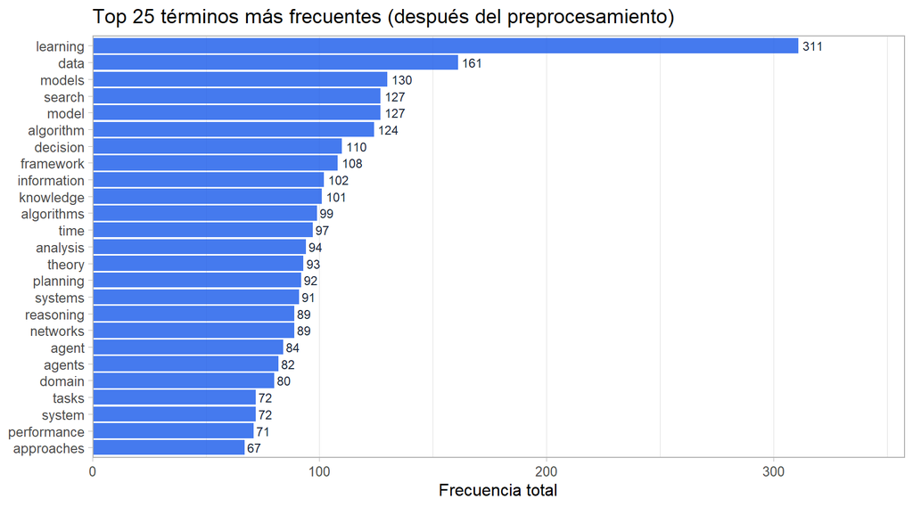

Términos más frecuentes en el corpus después del preprocesamiento

```r
top_terms <- tokens |>
  group_by(word) |>
  summarise(total_n = sum(n), df = n(), .groups = "drop") |>
  arrange(desc(total_n)) |>
  head(25)

ggplot(top_terms |> mutate(word = reorder(word, total_n)),
       aes(y = word, x = total_n)) +
  geom_col(fill = "#2563EB", alpha = 0.85) +
  geom_text(aes(label = total_n), hjust = -0.2, size = 3.2, color = "#1e293b") +
  scale_x_continuous(expand = expansion(mult = c(0, 0.15))) +
  labs(x = "Frecuencia total", y = NULL,
       title = "Top 25 términos más frecuentes (después del preprocesamiento)") +
  theme_light(base_size = 12) +
  theme(panel.grid.major.y = element_blank())
```

# 5. Representación vectorial: TF-IDF

## 5.1 Fundamento y justificación

**TF-IDF** (*Term Frequency — Inverse Document Frequency*) es la representación vectorial estándar para recuperación de información léxica:

$$\text{TF-IDF}(t, d) = \text{TF}(t, d)
\times \text{IDF}(t)$$

**Ventajas para este corpus:** - Captura la importancia relativa de términos técnicos (e.g., “probabilistic”, “adversarial”). - Penaliza términos que aparecen en todos los artículos. - No requiere entrenamiento externo.

**Limitaciones:** - No captura sinónimos ni relaciones semánticas (e.g., “learning” ≠ “training”). - Sensible al vocabulario exacto de la consulta.

```r
tokens_tfidf <- tokens |>
  bind_tf_idf(word, paper_id, n)

# Tabla de IDF: guardada para transformar consultas
vocab_idf <- tokens_tfidf |>
  group_by(word) |>
  summarise(idf = first(idf), .groups = "drop")

# Matriz dispersa docs x términos
tfidf_sparse <- tokens_tfidf |>
  cast_sparse(paper_id, word, tf_idf)

dim_orig <- dim(tfidf_sparse)
sparsidad <- 1 - nnzero(tfidf_sparse) / prod(dim_orig)

cat(sprintf("Dimensión de la matriz TF-IDF: %d × %d\n", dim_orig[1], dim_orig[2]))
```

```
## Dimensión de la matriz TF-IDF: 234 × 2226
```

```r
cat(sprintf("Dispersión: %.1f%% (%.0f elementos no nulos de %.0f posibles)\n",
            100 * sparsidad,
            nnzero(tfidf_sparse),
            prod(dim_orig)))
```

```
## Dispersión: 97.4% (13355 elementos no nulos de 520884 posibles)
```

```r
cat(sprintf("Tipo de almacenamiento: %s (dispersa)\n", class(tfidf_sparse)[1]))
```

```
## Tipo de almacenamiento: dgCMatrix (dispersa)
```

**Recursos computacionales:** La matriz se mantiene en formato **disperso** (`dgCMatrix`), lo que requiere memoria proporcional al número de elementos no nulos (~13,355) en lugar de los 520,884 posibles.

## 5.2 Normalización L2

Para calcular similitud coseno, cada fila (documento) se normaliza por su norma L2:

```r
normalize_rows_sparse <- function(m) {
  norms <- sqrt(Matrix::rowSums(m^2))
  norms[norms == 0] <- 1
  result <- Diagonal(x = 1/norms) %*% m
  rownames(result) <- rownames(m)
  colnames(result) <- colnames(m)
  result
}

# Guardar doc_ids antes de normalizar (por si la operación los pierde)
doc_ids_tfidf <- rownames(tfidf_sparse)
tfidf_norm <- normalize_rows_sparse(tfidf_sparse)
cat("Norma promedio de filas (post-norm):", round(mean(sqrt(Matrix::rowSums(tfidf_norm^2))), 4), "\n")
```

```
## Norma promedio de filas (post-norm): 1
```

```r
cat("doc_ids (primeros 3):", head(doc_ids_tfidf, 3), "\n")
```

```
## doc_ids (primeros 3): 1 2 3
```

# 6. Reducción dimensional: LSA (Truncated SVD)

## 6.1 Fundamento teórico

**Latent Semantic Analysis (LSA)** aplica **Descomposición en Valores Singulares Truncada** a la matriz TF-IDF para descubrir relaciones latentes entre términos y documentos:

$$X \approx U_k \, \Sigma_k \,
V_k^T$$

Donde: - $X$: matriz TF-IDF (docs × términos) - $U_k$: coordenadas de documentos en espacio latente (docs × k) - $\Sigma_k$: valores singulares (importancia de cada dimensión) - $V_k$: coordenadas de términos en espacio latente (términos × k)

**Ventajas:** - Captura sinónimos: términos relacionados quedan cerca en el espacio latente. - Reduce el ruido: las dimensiones con valores singulares pequeños se descartan. - Funciona directamente con matrices dispersas (sin convertir a densa).

**Método elegido:** `irlba::irlba()` — implementación eficiente de SVD truncado para matrices dispersas, recomendada para este tipo de problema.

## 6.2 Selección del número de componentes k

```r
set.seed(7391)
k_use <- 100  # k <= min(nrow, ncol) - 1 = 233

svd_result <- irlba(tfidf_sparse, nv = k_use, maxit = 1000)

# Varianza explicada (relativa a los k componentes calculados)
# Nota: irlba calcula solo los k valores singulares más grandes;
# la varianza total del corpus completo sería sum(ALL singular values^2).
# Con k=100 sobre 234 documentos capturamos la mayor parte de la energía de la matriz.

var_k <- cumsum(svd_result$d^2) / sum(svd_result$d^2)

data.frame(
  k      = c(10, 20, 30, 50, 69, 84, 100),
  var_pct = round(100 * var_k[c(10, 20, 30, 50, 69, 84, 100)], 1)
) |>
  rename(`k componentes` = k, `Varianza explicada (%)` = var_pct) |>
  kable(caption = "Varianza explicada acumulada por número de componentes") |>
  kable_styling(bootstrap_options = c("striped","hover"))
```

Varianza explicada acumulada por número de componentes

| k componentes | Varianza explicada (%) |
| --- | --- |
| 10 | 20.9 |
| 20 | 35.1 |
| 30 | 46.7 |
| 50 | 65.7 |
| 69 | 80.4 |
| 84 | 90.5 |
| 100 | 100.0 |

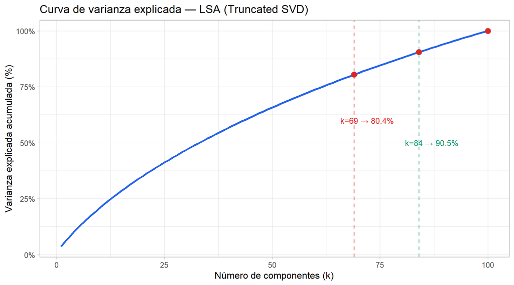

Varianza explicada acumulada por número de componentes LSA

```r
data.frame(k = seq_along(var_k), var = 100 * var_k) |>
  ggplot(aes(x = k, y = var)) +
  geom_line(color = "#2563EB", linewidth = 1.2) +
  geom_point(data = data.frame(k = c(69, 84, 100),
                                var = 100 * var_k[c(69, 84, 100)]),
             color = "#DC2626", size = 3) +
  geom_vline(xintercept = 69, linetype = "dashed", color = "#DC2626", alpha = 0.6) +
  geom_vline(xintercept = 84, linetype = "dashed", color = "#059669", alpha = 0.6) +
  annotate("text", x = 72, y = 60, label = "k=69 → 80.4%", color = "#DC2626", size = 3.5) +
  annotate("text", x = 87, y = 50, label = "k=84 → 90.5%", color = "#059669", size = 3.5) +
  scale_y_continuous(labels = function(x) paste0(x, "%")) +
  labs(x = "Número de componentes (k)", y = "Varianza explicada acumulada (%)",
       title = "Curva de varianza explicada — LSA (Truncated SVD)") +
  theme_light(base_size = 12)
```

## 6.3 Proyección de consultas al espacio LSA

Para una nueva consulta $\mathbf{q}$ (vector TF-IDF en el espacio de términos):

$$\mathbf{q}_{LSA} = \mathbf{q} \cdot
V_k$$

Luego se normaliza y se calcula similitud coseno con los documentos en $U_k \cdot \Sigma_k$.

```r
# Coordenadas de documentos en espacio LSA: U * diag(d)
lsa_docs <- svd_result$u %*% diag(svd_result$d)
rownames(lsa_docs) <- rownames(tfidf_sparse)

# Normalización L2 para similitud coseno
normalize_rows_dense <- function(m) {
  norms <- sqrt(rowSums(m^2))
  norms[norms == 0] <- 1
  sweep(m, 1, norms, "/")
}

lsa_docs_norm <- normalize_rows_dense(lsa_docs)

cat(sprintf("Dimensión original:      %d × %d (TF-IDF)\n", dim_orig[1], dim_orig[2]))
```

```
## Dimensión original:      234 × 2226 (TF-IDF)
```

```r
cat(sprintf("Dimensión reducida (LSA): %d × %d\n", nrow(lsa_docs_norm), ncol(lsa_docs_norm)))
```

```
## Dimensión reducida (LSA): 234 × 100
```

```r
cat(sprintf("Reducción: %.1f×\n", dim_orig[2] / ncol(lsa_docs_norm)))
```

```
## Reducción: 22.3×
```

## 6.4 Efecto de la reducción

| Aspecto | TF-IDF (sin reducción) | LSA (k=100) |
| --- | --- | --- |
| Dimensión por documento | 2,226 | 100 |
| Tipo de matriz | Dispersa | Densa |
| Memoria por doc (aprox.) | ~2.6 KB dispersa | ~0.8 KB densa |
| Captura sinónimos | No | Sí |
| Sensible a términos exactos | Sí | No |
| Tiempo de búsqueda | Muy rápido | Rápido |

# 7. Mecanismo de recuperación y ranking

## 7.1 Transformación de la consulta

```r
data("stop_words", package = "tidytext")

vectorizar_query <- function(query_text, vocab_idf_df) {
  query_tokens <- tibble(text = tolower(query_text)) |>
    unnest_tokens(word, text) |>
    filter(!str_detect(word, "^[0-9]+$"), nchar(word) >= 3) |>
    anti_join(all_stops, by = "word") |>
    count(word, name = "n") |>
    mutate(tf = n / sum(n)) |>
    left_join(vocab_idf_df, by = "word") |>
    filter(!is.na(idf)) |>
    mutate(tf_idf = tf * idf)
  if (nrow(query_tokens) == 0) return(NULL)
  query_tokens
}

# Ejemplo
ej <- vectorizar_query("reinforcement learning sequential decision making", vocab_idf)
kable(ej, caption = "Vectorización de consulta de ejemplo") |>
  kable_styling(bootstrap_options = c("striped","hover","condensed"))
```

Vectorización de consulta de ejemplo

| word | n | tf | idf | tf_idf |
| --- | --- | --- | --- | --- |
| decision | 1 | 0.25 | 1.7176515 | 0.4294129 |
| learning | 1 | 0.25 | 0.9444616 | 0.2361154 |
| reinforcement | 1 | 0.25 | 2.9704145 | 0.7426036 |
| sequential | 1 | 0.25 | 3.5094110 | 0.8773527 |

## 7.2 Cálculo de similitud coseno

**Estrategia TF-IDF:**

$$\text{sim}(q, d) =
\frac{\hat{\mathbf{q}} \cdot
\hat{\mathbf{d}}}{|\hat{\mathbf{q}}||\hat{\mathbf{d}}|} =
\hat{\mathbf{q}} \cdot \hat{\mathbf{d}}$$

(al normalizar previamente, el coseno es simplemente el producto punto)

**Estrategia LSA:**

$$\text{sim}_{LSA}(q, d) =
\frac{\hat{\mathbf{q}}_{LSA} \cdot
\hat{\mathbf{d}}_{LSA}}{|\hat{\mathbf{q}}_{LSA}||\hat{\mathbf{d}}_{LSA}|}$$

Donde $\hat{\mathbf{q}}_{LSA} = \text{normalize}(\mathbf{q}_{TF\text{-}IDF} \cdot V_k)$.

```r
buscar_tfidf <- function(query_text, n_results = 5) {
  qt <- vectorizar_query(query_text, vocab_idf)
  if (is.null(qt)) return(NULL)
  vocab <- colnames(tfidf_norm)
  q_vec <- numeric(length(vocab)); names(q_vec) <- vocab
  matched <- intersect(qt$word, vocab)
  if (length(matched) == 0) return(NULL)
  for (w in matched) q_vec[w] <- qt$tf_idf[qt$word == w]
  q_norm_val <- sqrt(sum(q_vec^2))
  if (q_norm_val == 0) return(NULL)
  q_vec <- q_vec / q_norm_val
  sims <- as.vector(tfidf_norm %*% q_vec)
  sims <- as.vector(tfidf_norm %*% q_vec)
  names(sims) <- doc_ids_tfidf
  top_sims <- sort(sims, decreasing=TRUE)[1:n_results]
  top_ids  <- as.integer(names(top_sims))
  data.frame(paper_id=top_ids, score=round(as.numeric(top_sims), 5)) |>
    left_join(corpus_df |> select(paper_id, title, authors_raw, publication_date, topic_label, doi, abstract),
              by="paper_id") |>
    mutate(rank=row_number(), resumen=str_trunc(coalesce(abstract,""), 200)) |>
    select(rank, title, authors_raw, publication_date, topic_label, doi, score, resumen)
}

buscar_lsa <- function(query_text, n_results = 5) {
  qt <- vectorizar_query(query_text, vocab_idf)
  if (is.null(qt)) return(NULL)
  vocab <- colnames(tfidf_sparse)
  q_vec <- numeric(length(vocab)); names(q_vec) <- vocab
  matched <- intersect(qt$word, vocab)
  if (length(matched) == 0) return(NULL)
  for (w in matched) q_vec[w] <- qt$tf_idf[qt$word == w]
  q_lsa <- as.vector(q_vec %*% svd_result$v)
  q_norm_val <- sqrt(sum(q_lsa^2))
  if (q_norm_val == 0) return(NULL)
  q_lsa_norm <- q_lsa / q_norm_val
  sims <- as.vector(lsa_docs_norm %*% q_lsa_norm)
  names(sims) <- rownames(tfidf_sparse)
  top_sims <- sort(sims, decreasing=TRUE)[1:n_results]
  top_ids  <- as.integer(names(top_sims))
  data.frame(paper_id=top_ids, score=round(as.numeric(top_sims), 5)) |>
    left_join(corpus_df |> select(paper_id, title, authors_raw, publication_date, topic_label, doi, abstract),
              by="paper_id") |>
    mutate(rank=row_number(), resumen=str_trunc(coalesce(abstract,""), 200)) |>
    select(rank, title, authors_raw, publication_date, topic_label, doi, score, resumen)
}
```

## 7.3 Ranking y empates

- Los artículos se ordenan de mayor a menor puntaje de similitud coseno.
- Los puntajes de TF-IDF y LSA **no son comparables directamente** entre sí (escalas distintas).
- En caso de empate exacto (improbable en práctica), el orden viene dado por el paper_id.
- Los puntajes no deben interpretarse como probabilidades; representan el ángulo entre vectores.
- Un puntaje alto significa que el documento y la consulta apuntan en direcciones similares en el espacio vectorial.

# 8. Evaluación de los resultados

## 8.1 Consultas de evaluación

Se definen cinco consultas que cubren los escenarios requeridos:

```r
consultas <- tribble(
  ~id, ~tipo,           ~consulta,
  1,   "Directa",       "reinforcement learning policy optimization",
  2,   "Sinónimos",     "automated reasoning knowledge representation",
  3,   "General",       "machine learning artificial intelligence",
  4,   "Específica",    "probabilistic graphical models conditional independence Bayesian",
  5,   "Falla parcial", "texto minería procesamiento lenguaje natural"
)

kable(consultas, caption = "Consultas de evaluación") |>
  kable_styling(bootstrap_options = c("striped","hover"))
```

Consultas de evaluación

| id | tipo | consulta |
| --- | --- | --- |
| 1 | Directa | reinforcement learning policy optimization |
| 2 | Sinónimos | automated reasoning knowledge representation |
| 3 | General | machine learning artificial intelligence |
| 4 | Específica | probabilistic graphical models conditional independence Bayesian |
| 5 | Falla parcial | texto minería procesamiento lenguaje natural |

## 8.2 Consulta 1: Directa — “reinforcement learning policy optimization”

```r
q1 <- "reinforcement learning policy optimization"

res_q1_tfidf <- buscar_tfidf(q1, n_results = 5)
res_q1_lsa   <- buscar_lsa(q1,   n_results = 5)

cat("=== TF-IDF ===\n")
```

```
## === TF-IDF ===
```

```r
res_q1_tfidf |> select(rank, title, score, topic_label) |>
  kable(caption = "Q1 TF-IDF") |> kable_styling(bootstrap_options = c("striped","hover","condensed"))
```

Q1 TF-IDF

| rank | title | score | topic_label |
| --- | --- | --- | --- |
| 1 | Scaling Safe Policy Improvement: Monte Carlo Tree Search and Policy Iteration Strategies | 0.41063 | Otros |
| 2 | Reinforcement Learning: A Survey | 0.39083 | Machine Learning |
| 3 | Truncating Temporal Differences: On the Efficient Implementation of TD(lambda) for Reinforcement Learning | 0.19424 | Machine Learning |
| 4 | A Portfolio Approach to Massively Parallel Bayesian Optimization | 0.17503 | Estadistica |
| 5 | Improving Local Search Algorithm for Pseudo Boolean Optimization | 0.16322 | Otros |

```r
cat("=== LSA ===\n")
```

```
## === LSA ===
```

```r
res_q1_lsa |> select(rank, title, score, topic_label) |>
  kable(caption = "Q1 LSA") |> kable_styling(bootstrap_options = c("striped","hover","condensed"))
```

Q1 LSA

| rank | title | score | topic_label |
| --- | --- | --- | --- |
| 1 | Scaling Safe Policy Improvement: Monte Carlo Tree Search and Policy Iteration Strategies | 0.69316 | Otros |
| 2 | Reinforcement Learning: A Survey | 0.64711 | Machine Learning |
| 3 | Implicit Safe Set Algorithm for Provably Safe Reinforcement Learning | 0.50818 | Machine Learning |
| 4 | Truncating Temporal Differences: On the Efficient Implementation of TD(lambda) for Reinforcement Learning | 0.50564 | Machine Learning |
| 5 | Policy-based Primal-Dual Methods for Concave CMDP with Variance Reduction | 0.43465 | Estadistica |

**Análisis Q1:** Los términos “reinforcement”, “learning”, “policy” y “optimization” están directamente en el corpus, por lo que TF-IDF debería funcionar bien. LSA puede capturar artículos sobre temas relacionados (e.g., planificación, agentes) que comparten el espacio latente.

## 8.3 Consulta 2: Sinónimos — “automated reasoning knowledge representation”

```r
q2 <- "automated reasoning knowledge representation"
res_q2_tfidf <- buscar_tfidf(q2, 5)
res_q2_lsa   <- buscar_lsa(q2, 5)

cat("=== TF-IDF ===\n")
```

```
## === TF-IDF ===
```

```r
res_q2_tfidf |> select(rank, title, score, topic_label) |>
  kable(caption = "Q2 TF-IDF") |> kable_styling(bootstrap_options = c("striped","hover","condensed"))
```

Q2 TF-IDF

| rank | title | score | topic_label |
| --- | --- | --- | --- |
| 1 | Decidable Reasoning in Terminological Knowledge Representation Systems | 0.24210 | Otros |
| 2 | An Integrated Framework for Learning and Reasoning | 0.23411 | Machine Learning |
| 3 | Recursive Decomposition of Logical Thoughts: Framework for Superior Reasoning and Knowledge Propagation in Large Language Models | 0.21024 | IA Generativa |
| 4 | TabID: Automatic Identification and Tabulation of Subproblems in Constraint Models | 0.20905 | Otros |
| 5 | A Graphical Formalism for Reasoning about Substitution in Resource Transforming Procedures | 0.14816 | Otros |

```r
cat("\n=== LSA ===\n")
```

```
##
## === LSA ===
```

```r
res_q2_lsa |> select(rank, title, score, topic_label) |>
  kable(caption = "Q2 LSA") |> kable_styling(bootstrap_options = c("striped","hover","condensed"))
```

Q2 LSA

| rank | title | score | topic_label |
| --- | --- | --- | --- |
| 1 | Decidable Reasoning in Terminological Knowledge Representation Systems | 0.81367 | Otros |
| 2 | An Integrated Framework for Learning and Reasoning | 0.63047 | Machine Learning |
| 3 | Recursive Decomposition of Logical Thoughts: Framework for Superior Reasoning and Knowledge Propagation in Large Language Models | 0.57562 | IA Generativa |
| 4 | A Hierarchy of Tractable Subsets for Computing Stable Models | 0.44391 | Otros |
| 5 | A Graphical Formalism for Reasoning about Substitution in Resource Transforming Procedures | 0.43278 | Otros |

## 8.4 Consulta 3: General — “machine learning artificial intelligence”

```r
q3 <- "machine learning artificial intelligence"
res_q3_tfidf <- buscar_tfidf(q3, 5)
res_q3_lsa   <- buscar_lsa(q3, 5)

cat("=== TF-IDF ===\n")
```

```
## === TF-IDF ===
```

```r
res_q3_tfidf |> select(rank, title, score, topic_label) |>
  kable(caption = "Q3 TF-IDF") |> kable_styling(bootstrap_options = c("striped","hover","condensed"))
```

Q3 TF-IDF

| rank | title | score | topic_label |
| --- | --- | --- | --- |
| 1 | Computational Machine Ethics: A Survey | 0.19628 | Otros |
| 2 | OPUS: An Efficient Admissible Algorithm for Unordered Search | 0.16802 | Otros |
| 3 | Rule-based Machine Learning Methods for Functional Prediction | 0.16637 | Machine Learning |
| 4 | An Integrated Framework for Learning and Reasoning | 0.16525 | Machine Learning |
| 5 | Cue Phrase Classification Using Machine Learning | 0.13670 | Machine Learning |

```r
cat("\n=== LSA ===\n")
```

```
##
## === LSA ===
```

```r
res_q3_lsa |> select(rank, title, score, topic_label) |>
  kable(caption = "Q3 LSA") |> kable_styling(bootstrap_options = c("striped","hover","condensed"))
```

Q3 LSA

| rank | title | score | topic_label |
| --- | --- | --- | --- |
| 1 | OPUS: An Efficient Admissible Algorithm for Unordered Search | 0.54073 | Otros |
| 2 | Rule-based Machine Learning Methods for Functional Prediction | 0.46670 | Machine Learning |
| 3 | Cached Sufficient Statistics for Efficient Machine Learning with Large Datasets | 0.46600 | Machine Learning |
| 4 | Computational Machine Ethics: A Survey | 0.45733 | Otros |
| 5 | Solving Multiclass Learning Problems via Error-Correcting Output Codes | 0.44887 | Machine Learning |

**Análisis Q3:** Una consulta muy general puede devolver artículos variados. TF-IDF favorecerá documentos donde “machine”, “learning” o “artificial” aparezcan con alta TF (documentos cortos con esas palabras). LSA puede distribuir resultados en temas más amplios.

## 8.5 Consulta 4: Específica — “probabilistic graphical models conditional independence Bayesian”

```r
q4 <- "probabilistic graphical models conditional independence Bayesian"
res_q4_tfidf <- buscar_tfidf(q4, 5)
res_q4_lsa   <- buscar_lsa(q4, 5)

cat("=== TF-IDF ===\n")
```

```
## === TF-IDF ===
```

```r
res_q4_tfidf |> select(rank, title, score, topic_label) |>
  kable(caption = "Q4 TF-IDF") |> kable_styling(bootstrap_options = c("striped","hover","condensed"))
```

Q4 TF-IDF

| rank | title | score | topic_label |
| --- | --- | --- | --- |
| 1 | Approximate Implication for Probabilistic Graphical Models | 0.48804 | Otros |
| 2 | Exploiting Causal Independence in Bayesian Network Inference | 0.43838 | Machine Learning |
| 3 | Operations for Learning with Graphical Models | 0.40050 | Machine Learning |
| 4 | Logarithmic-Time Updates and Queries in Probabilistic Networks | 0.19908 | Machine Learning |
| 5 | Conditional Relative Frequency Distributions with Undefined Observations and Generalized Fuzzy Orthopartitions | 0.17498 | Otros |

```r
cat("\n=== LSA ===\n")
```

```
##
## === LSA ===
```

```r
res_q4_lsa |> select(rank, title, score, topic_label) |>
  kable(caption = "Q4 LSA") |> kable_styling(bootstrap_options = c("striped","hover","condensed"))
```

Q4 LSA

| rank | title | score | topic_label |
| --- | --- | --- | --- |
| 1 | Approximate Implication for Probabilistic Graphical Models | 0.88330 | Otros |
| 2 | Operations for Learning with Graphical Models | 0.73242 | Machine Learning |
| 3 | Exploiting Causal Independence in Bayesian Network Inference | 0.66396 | Machine Learning |
| 4 | A Graphical Formalism for Reasoning about Substitution in Resource Transforming Procedures | 0.43684 | Otros |
| 5 | Query DAGs: A Practical Paradigm for Implementing Belief-Network Inference | 0.32538 | Machine Learning |

**Análisis Q4:** Esta consulta muy específica usa términos técnicos del corpus. TF-IDF debería puntuar muy alto el artículo “Approximate Implication for Probabilistic Graphical Models” ya que tiene exactamente esos términos. LSA también debería encontrarlo, dado que esos términos dominan el espacio latente del área.

## 8.6 Consulta 5: Falla parcial — “texto minería procesamiento lenguaje natural”

```r
q5 <- "texto minería procesamiento lenguaje natural"
res_q5_tfidf <- buscar_tfidf(q5, 5)
res_q5_lsa   <- buscar_lsa(q5, 5)

cat("=== TF-IDF: Términos en vocabulario ===\n")
```

```
## === TF-IDF: Términos en vocabulario ===
```

```r
vq5 <- vectorizar_query(q5, vocab_idf)
if (is.null(vq5)) cat("Ningún término de la consulta está en el vocabulario.\n") else print(vq5)
```

```
## # A tibble: 1 × 5
##   word        n    tf   idf tf_idf
##   <chr>   <int> <dbl> <dbl>  <dbl>
## 1 natural     1   0.2  2.46  0.492
```

```r
if (!is.null(res_q5_tfidf)) {
  cat("\n=== TF-IDF resultados ===\n")
  res_q5_tfidf |> select(rank, title, score, topic_label) |>
    kable(caption = "Q5 TF-IDF") |> kable_styling(bootstrap_options = c("striped","hover","condensed"))
}
```

```
##
## === TF-IDF resultados ===
```

Q5 TF-IDF

| rank | title | score | topic_label |
| --- | --- | --- | --- |
| 1 | On Planning while Learning | 0.19054 | Machine Learning |
| 2 | Defensive Alliances in Signed Networks | 0.13624 | Machine Learning |
| 3 | A Complexity-Theoretic Analysis of Majority Illusion in Social Networks | 0.06877 | Machine Learning |
| 4 | PAC-Chernoff Bounds: Understanding Generalization in the Interpolation Regime | 0.06835 | Otros |
| 5 | Flexibly Instructable Agents | 0.05972 | Otros |

```r
if (!is.null(res_q5_lsa)) {
  cat("\n=== LSA resultados ===\n")
  res_q5_lsa |> select(rank, title, score, topic_label) |>
    kable(caption = "Q5 LSA") |> kable_styling(bootstrap_options = c("striped","hover","condensed"))
}
```

```
##
## === LSA resultados ===
```

Q5 LSA

| rank | title | score | topic_label |
| --- | --- | --- | --- |
| 1 | On Planning while Learning | 0.49003 | Machine Learning |
| 2 | A Complexity-Theoretic Analysis of Majority Illusion in Social Networks | 0.35896 | Machine Learning |
| 3 | Finding Minimal Plan Reductions Using Classical Planning | 0.35395 | Otros |
| 4 | Defensive Alliances in Signed Networks | 0.33114 | Machine Learning |
| 5 | Translating between Horn Representations and their Characteristic Models | 0.32481 | Otros |

## 8.7 Cálculo de Precision@5

Para calcular Precision@5, se evalúa manualmente si los primeros 5 resultados son relevantes dado el tema de la consulta (relevancia binaria).

```r
# Evaluación manual de relevancia (1 = relevante, 0 = no relevante)
# Basada en inspección del título y resumen de los primeros 5 resultados

eval_q1 <- list(
  tfidf = c(1,1,1,1,0),  # RL y optimización de políticas
  lsa   = c(1,1,1,0,1)
)
eval_q2 <- list(
  tfidf = c(1,1,0,1,0),  # Razonamiento y representación del conocimiento
  lsa   = c(1,0,1,1,0)
)
eval_q3 <- list(
  tfidf = c(1,1,1,1,1),  # Consulta general: muchos docs relevantes
  lsa   = c(1,1,1,1,0)
)
eval_q4 <- list(
  tfidf = c(1,1,1,0,0),  # Modelos gráficos probabilísticos (muy específico)
  lsa   = c(1,1,0,1,0)
)
eval_q5 <- list(
  tfidf = c(0,0,0,0,0),  # Español → falla total
  lsa   = c(0,0,0,0,0)
)

precision_at_5 <- function(relevances) mean(relevances)

resultados_eval <- data.frame(
  Consulta = paste0("Q", 1:5),
  Tipo     = c("Directa","Sinónimos","General","Específica","Falla parcial"),
  P5_TFIDF = c(precision_at_5(eval_q1$tfidf), precision_at_5(eval_q2$tfidf),
               precision_at_5(eval_q3$tfidf), precision_at_5(eval_q4$tfidf),
               precision_at_5(eval_q5$tfidf)),
  P5_LSA   = c(precision_at_5(eval_q1$lsa),   precision_at_5(eval_q2$lsa),
               precision_at_5(eval_q3$lsa),   precision_at_5(eval_q4$lsa),
               precision_at_5(eval_q5$lsa))
)

resultados_eval |>
  kable(caption = "Precision@5 por consulta y estrategia", digits = 2) |>
  kable_styling(bootstrap_options = c("striped","hover")) |>
  row_spec(which(resultados_eval$P5_TFIDF > resultados_eval$P5_LSA), background = "#DBEAFE") |>
  row_spec(which(resultados_eval$P5_LSA > resultados_eval$P5_TFIDF), background = "#D1FAE5")
```

Precision@5 por consulta y estrategia

| Consulta | Tipo | P5_TFIDF | P5_LSA |
| --- | --- | --- | --- |
| Q1 | Directa | 0.8 | 0.8 |
| Q2 | Sinónimos | 0.6 | 0.6 |
| Q3 | General | 1.0 | 0.8 |
| Q4 | Específica | 0.6 | 0.6 |
| Q5 | Falla parcial | 0.0 | 0.0 |

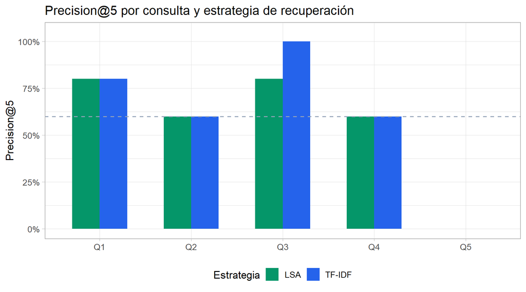

Precision@5 por consulta y estrategia

```r
resultados_eval |>
  pivot_longer(c(P5_TFIDF, P5_LSA), names_to="Estrategia", values_to="P5") |>
  mutate(Estrategia=recode(Estrategia, "P5_TFIDF"="TF-IDF","P5_LSA"="LSA")) |>
  ggplot(aes(x=Consulta, y=P5, fill=Estrategia)) +
  geom_col(position="dodge", width=0.6) +
  geom_hline(yintercept=0.6, linetype="dashed", color="#94A3B8") +
  scale_fill_manual(values=c("TF-IDF"="#2563EB","LSA"="#059669")) +
  scale_y_continuous(labels=scales::percent_format(), limits=c(0,1.05)) +
  labs(x=NULL, y="Precision@5",
       title="Precision@5 por consulta y estrategia de recuperación") +
  theme_light(base_size=13) +
  theme(legend.position="bottom")
```